# Proyecto final DDS R y Python

Proyeccion del precio de la carne en el mercado ganadero Uruguayo para el periodo 2022-2025

Maria de los Angeles Gomez

2024-01-23

[figure not shown]

## Resumen

El proyecto de la Diplomatura de Data Science con R y Python forma parte de los recaudos para la finalización del curso. Este proyecto esta desarrollado en Rmardown con ambos lenguajes de programación R y Python, la necesidad planteada surge a partir de la importancia en la República Oriental del Uruguay de las inversiones en el negocio ganadero, constituyendo hoy en día alternativa de ahorro e inversión tanto para el empresario como para el ciudadano común con o sin conocimiento en el mercado. Para la el proyecto exploramos con **R** y **Python** varios algoritmos de regresión, para posteriormente comparar sus resultados y tomar el de menor desvío como el óptimo para la proyeccción.

> Metodología

El proyecto se realizó con los lenguajes de programación R y Python, en el siguiente orden:

1. Análisis y compresión del problema.
2. Construcción y obtención de datos de fuentes oficiales.
3. Exploración de datos.
4. Limpieza y preparación del Dataset.
5. Exploración de algoritmos.
6. Registro de resultados - Predicciones 2022-2025
7. Interpretación y conclusiones.
8. Presentación de resultados.

## Ficha técnica

### Análisis y compresión del problema

Un productor del departamento de Colonia nos ha contactado para saber si le conviene invertir en ganado para cría y engorde, con proyección de venta al 2.025, considerando la baja que se registra desde el 2.022 en las exportaciones al mercado Chino, principal destino de las exportaciones de ganado en la actualidad. La otra alternativa de inversion para el productor es colocar el dinero a plazo fijo por cinco años que le promete un retorno del 8% anual.

Para ello hemos planteado hacer una proyección del precio promedio de exportacion por kilo que nos permita inferir las ventas y el retorno de la venta final.

> Problema

Estimar el precio promedio de exportacion por kilo futuro, a partir de la venta de ganado en pie para mercados extranjeros.

> Matriz de valoracion

- Uruguay mantiene la cuota de venta de ganado al mercado internacional.
- No ocurran muertes en el rebaño por enfermedades extraordinarias o epidemias.
- Ganado bovino con las mismas caracteristicas físicas peso, raza, sexo, clase, estado, nutrición, sanidad, homogeneidad, calidad, etc.)
- La inversion que tiene en mente el productor es de unos 10.000 dolares.
- El valor de rentabilidad por inversion debe ser superior al 8% que ofrece el banco, el productor espera como minimo el doble de la tasa que paga el banco.

Cada kilo de carne en el mercado internacional se vende en 4 dólares en promedio, el costo para producir cada kilo es de 3 dólares(reposición, alimentación y sanidad) por lo que la renta neta mínima esperada después de impuestos es de 1 dólar por kilo, esto es cerca del 25% del valor de produccion, a su vez cada bovino de 3 años pesa en promedio 300 kilos, *para mayor información ver* [Dinámica de los pesos de ganado vacuno de reposición en los remates por pantalla en Uruguay](https://acortar.link/tIW3To).

El valor esperado total de retorno por la inversión por cada punto del precio es de 638 dólares, esto siginifca que cada dólar de venta debe multiplicarse por este precio para calcular el valor final esperado de rentabilidad total por la inversión.

> **Matriz de valoración esperada**

Fuente: Elaboracion propia

[output not shown]

## Objetivo de Machine Learning

1. Predecir el precio del kilo de carne de exportación para el año 2022-2025.

## Construcción y obtención de datos de fuentes oficiales

> Base de datos
- **Pais**: Uruguay
- **Periodo**: El dataset esta comprendido por datos de los años que van del 2001 al 2021.
- **Cantidad de observaciones**: 21
- **Fuente**:

  *Uruguay XXI*

  *FAO*

  [*https://www.bcu.gub.uy/Estadisticas-e-Indicadores/Paginas/Cotizaciones.aspx*](https://www.bcu.gub.uy/Estadisticas-e-Indicadores/Paginas/Cotizaciones.aspx)

  [*https://www.inac.uy/innovaportal/v/15205/10/innova.front/relacion-hacienda_exportacion—rhe-bovinos*](https://www.inac.uy/innovaportal/v/15205/10/innova.front/relacion-hacienda_exportacion---rhe-bovinos)

> Variables explicativas o predictivas
1. **Año**: año de observación.
2. **Demanda total en cantidades de carne vacuna desde China,continental**: Carne, ganado vacuno, fresca o refrigerada, expresada en toneladas.FAO
3. **Exportación de carne de Estados Unidos**, expresada en cabezas de ganado vacuno.FAO
4. **Ingreso medio de exportacion de carne bovina**. en U$D por kilo. INAC datos del 2005-2021.
5. **Indice de calentamiento año meteorológico**. Variación de temperatura de la superficie terrestre expresado en grados C°. FAO
6. **Total de ganado vacuno exportado desde Uruguay**, expresado en cabezas de ganado.FAO
7. **Evolución del dólar en Uruguay**. billete dólar para la compra.BCU
8. **Exportaciones de ganado vacuno en pie desde Uruguay en miles de dólares**.FAO
9. **Exportacion de Carne, vacuno deshuesada, fresca o refrigerada desde Uruguay** expresado en toneladas.FAO
10. **Exportacion de Carne, vacuno deshuesada, fresca o refrigerada desde Uruguay** expresado en miles de U$D.FAO
11. **Variación anual del IMEX bovino**, expresado en porcentaje.elaboracion propia

*En relacion a los datos faltantes para la serie del ingreso promedio de exportacion de carne bovina se usaron tecnicas de distribucion normal inversa con semilla aleatoria para calcular los valores correspondientes a 2001,2002,2003,2004. que representan el 19% de los datos.*

**La variable objetivo es el precio del Ingreso medio de exportacion de carne bovina para el 2.023**. en U$D.

> Diccionario de Variables

Nomeclatura de variables usadas

| Variable | Nomeclatura DF |
| --- | --- |
| **Año** | **Anio** |
| **Demanda total en cantidades de carne vacuna desde China** | **Imp_China** |
| **Exportación de carne desde Estados Unidos al mundo** | **Export_ EEUU** |
| **Total de ganado vacuno exportado desde Uruguay en cabezas** | **Ex_UGY_GV_C** |
| **Total de ganado vacuno exportado desde Uruguay en miles de dólares** | **Ex_UGY_GV_U$D** |
| **Exportacion de Carne, vacuno deshuesada, fresca o refrigerada desde Uruguay** en toneladas | **Ex_UGY_CF_Tn** |
| **Exportacion de Carne, vacuno deshuesada, fresca o refrigerada desde Uruguay en dólares** | **Ex_UGY_CF_U$D** |
| **Indice de calentamiento año meteorológico** | **Var_C°** |
| **Ingreso medio de exportacion de carne bovina en dólares** | **Imex_Bov** |
| **Variación anual del ingreso medio de exportacion de carne bovina en %** | **Var_anual_RHE** |
| **Evolución del dólar en Uruguay** | **U$D/UGY** |

> Metrica de evaluacion

RMSE mide la cantidad de errores que existen entre el valor de la prediccion y el valor observado, mientras mas pequeño es este valor mas cercana se encuentra la prediccion de los valores reales.

> Formula de calculo

## Exploración y análisis de los datos

Para la preparación de los datos usaremos ambos lenguajes de programación R y Python.

Trabajaremos con las librerias:

- Lenguaje R: skimr, tidyverse, tidymodels, DataExplorer, entre otras.
- Python: numpy, pandas, seaborn, sklearn, entre otras.

Cargamos las librerias necesarias para trabajar con ambos lenguajes;

```r
library(reticulate)
library(readxl)
library(skimr)
library(PerformanceAnalytics)
```

```r
library(corrplot)
library(ggplot2)
library(writexl)
library(neuralnet)
library(caret)
library(nnet)
```

```python
import numpy as np
import pandas as pd
import seaborn as sns
import openpyxl
import matplotlib.pyplot as plt
import matplotlib as mpl
from sklearn.model_selection import train_test_split
from sklearn.ensemble import RandomForestRegressor
from sklearn.metrics import mean_squared_error

#warnings
import warnings
warnings.filterwarnings("ignore")
```

Carga de datos en R

```r
dfr <- read_excel("C:/Users/maria/OneDrive/Escritorio/Sourceowm/Capacitaciones/DDS/Proyecto/Proyecto/DF.xlsx")
```

Carga de datos en python

```python
dfpy = pd.read_excel("C:/Users/maria/OneDrive/Escritorio/Sourceowm/Capacitaciones/DDS/Proyecto/Proyecto/DF.xlsx")
```

> Visual del Dataset

```python
dfpy.head(5).T
```

```
##                              0              1  ...              3              4
## Anio                  2001.000    2002.000000  ...    2004.000000    2005.000000
## Imp_China               97.000     174.000000  ...      98.000000      80.000000
## Export_ EEUU        679190.000  243394.000000  ...   30236.000000   21230.000000
## Ex_UGY_GV_C          11755.000   11763.000000  ...   42814.000000   11466.000000
## Ex_UGY_GV_U$D         3899.000    3192.500000  ...    9102.000000    4676.000000
## Ex_UGY_CF_Tn         87816.000  145049.000000  ...  233068.000000  275976.000000
## Ex_UGY_CF_U$D       190378.000  249723.000000  ...  596979.000000  729414.000000
## Var_C                    1.226       0.610000  ...       0.458000       0.802000
## U$D/UGY                 14.760      27.170000  ...      26.380000      24.120000
## Imex_bov                 1.810       1.610000  ...       1.630000       1.797000
## Var_anual_Imex_bov       0.110      -0.110497  ...       0.147887       0.102454
##
## [11 rows x 5 columns]
```

Veamos la información del dataset para analizar un poco mejor.

```python
dfpy.info()
```

```
## <class 'pandas.core.frame.DataFrame'>
## RangeIndex: 21 entries, 0 to 20
## Data columns (total 11 columns):
##  #   Column              Non-Null Count  Dtype
## ---  ------              --------------  -----
##  0   Anio                21 non-null     int64
##  1   Imp_China           21 non-null     float64
##  2   Export_ EEUU        21 non-null     int64
##  3   Ex_UGY_GV_C         21 non-null     int64
##  4   Ex_UGY_GV_U$D       21 non-null     float64
##  5   Ex_UGY_CF_Tn        21 non-null     float64
##  6   Ex_UGY_CF_U$D       21 non-null     int64
##  7   Var_C               21 non-null     float64
##  8   U$D/UGY             21 non-null     float64
##  9   Imex_bov            21 non-null     float64
##  10  Var_anual_Imex_bov  21 non-null     float64
## dtypes: float64(7), int64(4)
## memory usage: 1.9 KB
```

El Dataset se compone de 21 filas y 11 columnas, tenemos 4 variables que son de tipo integer y 7 de tipo float, sin embargo, la variable año si bien esta numérica para el caso en estudio es una variable categórica ordinal por lo que realizaremos esta transformación, el resto de las variables entendemos que tiene el formato adecuado para trabajar.

### Transformación y adecuación del Dataset

Cambiar la variable año a categorica:

```python
dfpy['Anio'] = pd.Categorical(dfpy['Anio'])
```

veamos un poco la distribución original de algunas variables, así como los estadísticos de las mismas.

```r
dfr2 <- py$dfpy
summary(dfr2)
```

```
##       Anio      Imp_China       Export_ EEUU     Ex_UGY_GV_C
##  2001   : 1   Min.   :    61   Min.   : 21230   Min.   : 11466
##  2002   : 1   1st Qu.:   181   1st Qu.: 69559   1st Qu.: 42814
##  2003   : 1   Median :  2179   Median :107821   Median :167293
##  2004   : 1   Mean   : 78369   Mean   :181809   Mean   :154200
##  2005   : 1   3rd Qu.:101560   3rd Qu.:243394   3rd Qu.:227444
##  2006   : 1   Max.   :422183   Max.   :679190   Max.   :385157
##  (Other):15
##  Ex_UGY_GV_U$D     Ex_UGY_CF_Tn    Ex_UGY_CF_U$D         Var_C
##  Min.   :  2486   Min.   : 87816   Min.   : 190378   Min.   :0.1310
##  1st Qu.: 15146   1st Qu.:219086   1st Qu.: 787943   1st Qu.:0.4470
##  Median : 78565   Median :239653   Median :1231165   Median :0.7190
##  Mean   : 90838   Mean   :237085   Mean   :1091219   Mean   :0.7027
##  3rd Qu.:140149   3rd Qu.:263732   3rd Qu.:1371534   3rd Qu.:0.8900
##  Max.   :271040   Max.   :339748   Max.   :2096074   Max.   :1.5460
##
##     U$D/UGY         Imex_bov     Var_anual_Imex_bov
##  Min.   :14.76   Min.   :1.420   Min.   :-0.20305
##  1st Qu.:21.42   1st Qu.:1.976   1st Qu.:-0.04171
##  Median :24.42   Median :3.446   Median : 0.05500
##  Mean   :26.74   Mean   :3.032   Mean   : 0.06520
##  3rd Qu.:29.34   3rd Qu.:3.711   3rd Qu.: 0.11000
##  Max.   :44.61   Max.   :4.830   Max.   : 0.48536
##
```

## Graficas

> Primero observemos la correlacion entre las variables

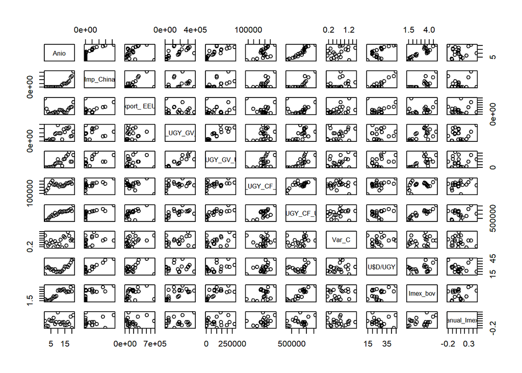

```r
pairs(dfr2) #aca no podemos apreciar mucho las correlaciones entre variables
```

Si bien no deja ver todas las correlaciones, se puede observar por ejemplo la alta correlacion positiva que existe entre las exportaciones de Uruguay y las importaciones desde China, pero no de ganado vacuno en pie, sino de las exportaciones de carne Uruguaya en carne vacuno deshuesada, fresca o refrigerada.

```python
dfpy.corr()
```

```
##                     Imp_China  Export_ EEUU  ...  Imex_bov  Var_anual_Imex_bov
## Imp_China            1.000000      0.494187  ...  0.680355            0.132119
## Export_ EEUU         0.494187      1.000000  ...  0.229739            0.122020
## Ex_UGY_GV_C          0.299930     -0.081817  ...  0.654697            0.174106
## Ex_UGY_GV_U$D        0.612347      0.137917  ...  0.707672            0.070683
## Ex_UGY_CF_Tn         0.533814     -0.274765  ...  0.458638            0.284036
## Ex_UGY_CF_U$D        0.745005      0.099445  ...  0.908716            0.183355
## Var_C                0.328486      0.423240  ...  0.195928           -0.196674
## U$D/UGY              0.889447      0.244889  ...  0.407459           -0.063167
## Imex_bov             0.680355      0.229739  ...  1.000000            0.265610
## Var_anual_Imex_bov   0.132119      0.122020  ...  0.265610            1.000000
##
## [10 rows x 10 columns]
```

```r
dfr3 <- subset(x = dfr2,
               select = -c(Anio))
```

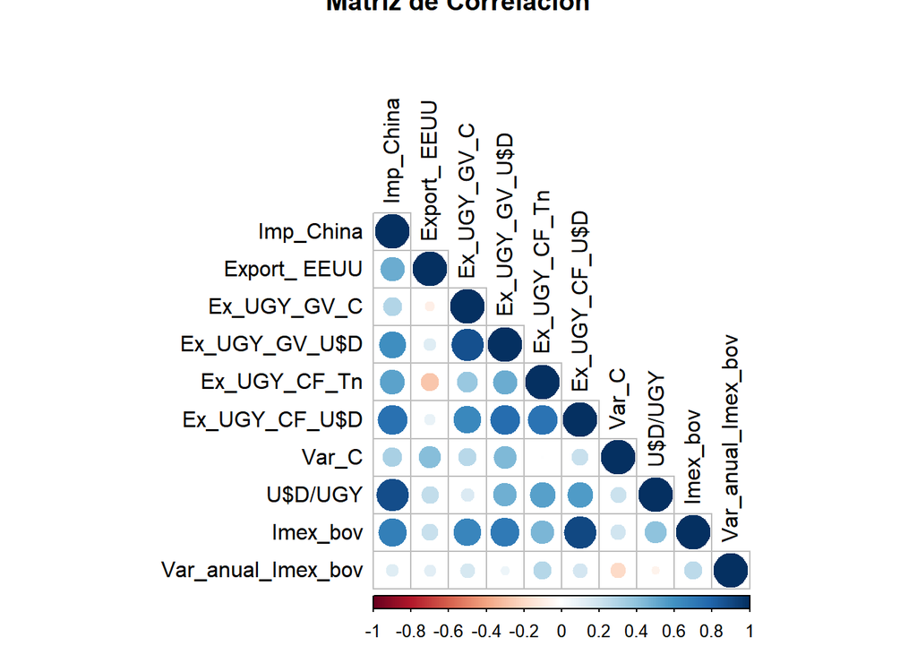

```r
corrplot(cor(dfr3),
         method = "circle",
         type = "lower",
         diag = TRUE,
         tl.col = "black",
         bg = "white",
         title = "Matriz de Correlacion",
         col = NULL)
```

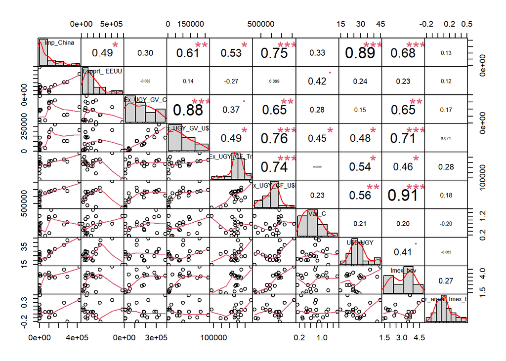

```r
chart.Correlation(dfr3, histogram = TRUE, method = "pearson")
```

De aca podemos sacar algunas conclusiones, la primera es que las variables seleccionadas para explicar el indice promedio de exportacion por carne vacuna aparentan tener relacion con la causalidad de los valores que toma, sin embargo hay que ser cuidadosos, ya que nunca una correlacion positiva o negativa se debe interpretar como causalidad. Partiendo de esta aclaracion hacemos los siguientes apartados:

- Se observa una asociacion de hecho positiva entre la evolucion del dolar y el incremento en el monto total de exportaciones, lo cual tendria sentido ya que un empresario recibe mayor pago por cada bien o servicio exportado a medida que el dolar sube y la moneda se devalua. esto lo podemos evidenciar por ejemplo en la correlacion de 0,91 que tienen las variables Imex_bov & Ex_UGY_CF_U$D.
- Para trabajar en los distintos algoritmos, vamos a excluir a todas las variables con correlacion superior a 0.7 ya que nos es dificil saber cual de las dos esta generando la explicabilidad de la otra.

Calculamos la correlacion las variables con la variable objetivo Imex_bov

```python
corr_matriz = dfpy.corr()
dfpycorr = pd.DataFrame(dfpy.corrwith(dfpy['Imex_bov'],axis=0),columns=['Correlacion'])
```

Observamos cuales son las variables que eliminaremos de nuestro dataset para el entrenamiento de los algoritmos

```python
dfpycorr[abs(dfpycorr['Correlacion']) > 0.7]
```

```
##                Correlacion
## Ex_UGY_GV_U$D     0.707672
## Ex_UGY_CF_U$D     0.908716
## Imex_bov          1.000000
```

Entonces repasando la exploracion de datos tenemos un dataset de 11 columnas, 21 observaciones, sin datos nulos, por lo que ya tendriamos el data set listo para iniciar el entrenamiento. Antes de pasar a los algoritmos observemos la distribucion de nuestra variable objetivo, respecto a las otras

```r
density(dfr3$Imex_bov)
```

```
##
## Call:
##  density.default(x = dfr3$Imex_bov)
##
## Data: dfr3$Imex_bov (21 obs.);   Bandwidth 'bw' = 0.51
##
##        x                y
##  Min.   :-0.110   Min.   :0.0004561
##  1st Qu.: 1.507   1st Qu.:0.0253510
##  Median : 3.125   Median :0.1694751
##  Mean   : 3.125   Mean   :0.1543818
##  3rd Qu.: 4.743   3rd Qu.:0.2525041
##  Max.   : 6.360   Max.   :0.3679814
```

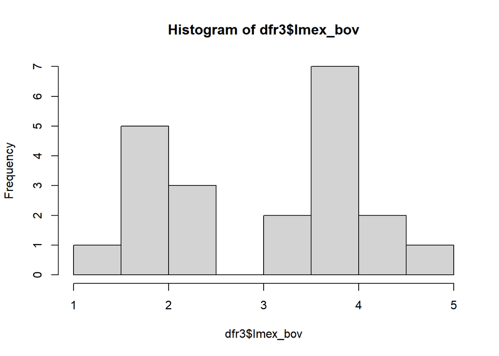

```r
hist(dfr3$Imex_bov)
```

En la grafica observamos que la serie no toma valores de 2.5 en ninguno de los años observados, por otra parte el valor con mayor frecuencia esta entre 3.5 y 4, pero como esta variable es continua no es correcto verlo en un histograma con tanto corte, veamos como se observa en un grafico de densidad.

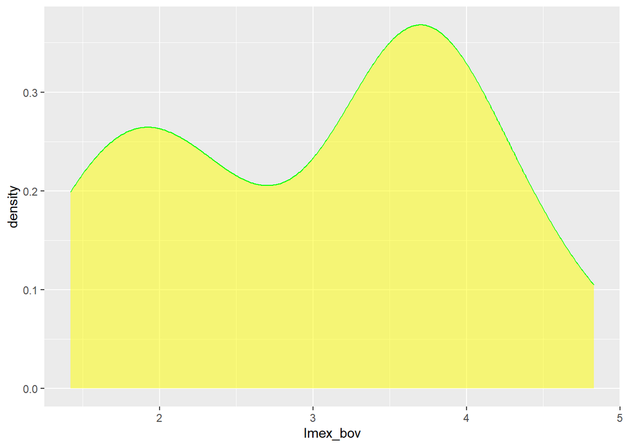

```r
ggplot(dfr3, aes(x = Imex_bov)) +
  geom_density(color = 'green', fill = 'yellow', alpha = 0.5)
```

Nos genera una grafica bimodal, con concentracion en los valores 2 y 3.7 aproximadamente en el periodo observado, esto viendo los datos sin la presencia del anio, ya que entre estas dos variables se observa una relacion lineal positiva, como vimos en el plot superior.

## Preparación del Dataset

Los procesos que haremos son:

- dropear las variables que encontramos con una correlacion por encima de 0.7.

```python
dfpy.info()
```

```
## <class 'pandas.core.frame.DataFrame'>
## RangeIndex: 21 entries, 0 to 20
## Data columns (total 11 columns):
##  #   Column              Non-Null Count  Dtype
## ---  ------              --------------  -----
##  0   Anio                21 non-null     category
##  1   Imp_China           21 non-null     float64
##  2   Export_ EEUU        21 non-null     int64
##  3   Ex_UGY_GV_C         21 non-null     int64
##  4   Ex_UGY_GV_U$D       21 non-null     float64
##  5   Ex_UGY_CF_Tn        21 non-null     float64
##  6   Ex_UGY_CF_U$D       21 non-null     int64
##  7   Var_C               21 non-null     float64
##  8   U$D/UGY             21 non-null     float64
##  9   Imex_bov            21 non-null     float64
##  10  Var_anual_Imex_bov  21 non-null     float64
## dtypes: category(1), float64(7), int64(3)
## memory usage: 2.5 KB
```

```python
dfpy2 = dfpy.drop(['Ex_UGY_GV_U$D','Ex_UGY_CF_U$D', 'Anio'], axis=1)
```

- Renombrar las variables que tienen caracteres especiales

```python
dfpy2 =  dfpy2.rename(columns={'Var_C' : 'Var_C'})
dfpy2 =  dfpy2.rename(columns={'U$D/UGY' : 'UD_UGY'})
dfpy2 =  dfpy2.rename(columns={'Export_ EEUU' : 'Export_EEUU'})
```

- Pasar a todas las variables de float a numerico

```python
dfpy2.info()
```

```
## <class 'pandas.core.frame.DataFrame'>
## RangeIndex: 21 entries, 0 to 20
## Data columns (total 8 columns):
##  #   Column              Non-Null Count  Dtype
## ---  ------              --------------  -----
##  0   Imp_China           21 non-null     float64
##  1   Export_EEUU         21 non-null     int64
##  2   Ex_UGY_GV_C         21 non-null     int64
##  3   Ex_UGY_CF_Tn        21 non-null     float64
##  4   Var_C               21 non-null     float64
##  5   UD_UGY              21 non-null     float64
##  6   Imex_bov            21 non-null     float64
##  7   Var_anual_Imex_bov  21 non-null     float64
## dtypes: float64(6), int64(2)
## memory usage: 1.4 KB
```

```r
dfr4 <- py$dfpy2
dfr4$Imp_China <- as.numeric(dfr4$Imp_China)
dfr4$Ex_UGY_CF_Tn <- as.numeric(dfr4$ Ex_UGY_CF_Tn)
dfr4$Var_C <- as.numeric(dfr4$Var_C)
dfr4$UD_UGY  <- as.numeric(dfr4$UD_UGY )
dfr4$Var_anual_Imex_bov  <- as.numeric(dfr4$Var_anual_Imex_bov )
```

- Estandarizar a todas las variables, para quitar cualquier peso que pueda influir en el entrenamiento y por ende en los resultados finales, para ello crearemos primero la funcion de estandarizado

```r
estandarizado <- function(x){
  resultado <- (x - mean(x))/(sd(x))
  return(resultado)
}
```

```r
dfr4$Imp_China <- estandarizado(dfr4$Imp_China)
dfr4$Ex_UGY_CF_Tn <- estandarizado(dfr4$ Ex_UGY_CF_Tn)
dfr4$Var_C <- estandarizado(dfr4$Var_C)
dfr4$UD_UGY  <- estandarizado(dfr4$UD_UGY)
dfr4$Var_anual_Imex_bov  <- estandarizado(dfr4$Var_anual_Imex_bov)
dfr4$Export_EEUU <- estandarizado(dfr4$Export_EEUU)
dfr4$Ex_UGY_GV_C  <- estandarizado(dfr4$Ex_UGY_GV_C)
```

> Visual del Dataset estandarizado

```r
print(dfr4)
```

```
##     Imp_China Export_EEUU Ex_UGY_GV_C Ex_UGY_CF_Tn       Var_C      UD_UGY
## 1  -0.6593968  3.01628004  -1.1870573  -2.80238192  1.36222456 -1.57925977
## 2  -0.6587481  0.37347348  -1.1869906  -1.72789060 -0.24120919  0.05733514
## 3  -0.6586892 -0.49038896  -1.1869239  -1.08197174 -0.98566057  0.33691461
## 4  -0.6593884 -0.91918492  -0.9282280  -0.07542346 -0.63686167 -0.04684777
## 5  -0.6595400 -0.97380019  -1.1894656   0.73013056  0.25856237 -0.34489004
## 6  -0.6597001 -0.80270146  -0.8592435   1.21861080 -0.30368063 -0.30532690
## 7  -0.6581753 -0.69843760  -0.9038443   0.11278571 -1.48803511 -0.69040806
## 8  -0.6552267 -0.45029773   0.1091141   0.02813382  0.04251529 -0.31323953
## 9  -0.6554710 -0.75073629   0.2577332   0.31648341 -0.50671283 -0.93701825
## 10 -0.6422616 -0.56117777   1.9246773  -0.08882809 -1.14964811 -0.87503601
## 11 -0.6418572  0.05588502   0.2783586  -0.47085985 -0.66549442 -0.90141143
## 12 -0.5733670  0.05818946   0.2914004   0.04820321  0.34706358 -0.96734999
## 13 -0.1451474 -0.10332764  -0.9393782  -0.42736053 -1.44118152 -0.70095823
## 14  0.1621606 -0.44868463   1.0719133  -0.33791377  1.19563404 -0.31323953
```

[output cut: 29 more lines]

Exportaremos el Dataset Final para usarlo en el entrenamiento de datos con Python posteriormente

```r
#write_xlsx(dfr4,"C:/Users/maria/OneDrive/Escritorio/Sourceowm/Capacitaciones/DDS/Proyecto/Proyecto/DFF.xlsx")
```

## Exploración de algoritmos con Python

Iniciaremos la exploracion de algoritmos con el Dataset que hemos preparado, los algoritmos con los que intentaremos son, LGBM de Microsoft y Random Forest.

```python
RFO = dfpy
```

### Random Forest DF original

```python
RFO.info()
```

```
## <class 'pandas.core.frame.DataFrame'>
## RangeIndex: 21 entries, 0 to 20
## Data columns (total 11 columns):
##  #   Column              Non-Null Count  Dtype
## ---  ------              --------------  -----
##  0   Anio                21 non-null     category
##  1   Imp_China           21 non-null     float64
##  2   Export_ EEUU        21 non-null     int64
##  3   Ex_UGY_GV_C         21 non-null     int64
##  4   Ex_UGY_GV_U$D       21 non-null     float64
##  5   Ex_UGY_CF_Tn        21 non-null     float64
##  6   Ex_UGY_CF_U$D       21 non-null     int64
##  7   Var_C               21 non-null     float64
##  8   U$D/UGY             21 non-null     float64
##  9   Imex_bov            21 non-null     float64
##  10  Var_anual_Imex_bov  21 non-null     float64
## dtypes: category(1), float64(7), int64(3)
## memory usage: 2.5 KB
```

```python
RFO.sample(3)
```

```
##     Anio  Imp_China  Export_ EEUU  ...  U$D/UGY  Imex_bov  Var_anual_Imex_bov
## 1   2002     174.00        243394  ...    27.17     1.610           -0.110497
## 17  2018  164817.07        244419  ...    32.44     3.446           -0.034193
## 9   2010    2131.00         89271  ...    20.10     3.703            0.485359
##
## [3 rows x 11 columns]
```

definimos las variables explicativas y la variable objetivo

```python
X = RFO.drop(['Imex_bov', 'Anio'], axis = 1)
y = RFO['Imex_bov']
```

Partimos el Dataset de entrenamiento y el de validacion

```python
X_train, X_test, y_train, y_test = train_test_split(X,y, test_size = 0.20)
```

```python
X_train.shape
```

```
## (16, 9)
```

Construimos el modelo

```python
RF_mod = RandomForestRegressor(
                  n_estimators = 100,
                  criterion = 'squared_error',
                  max_depth = None,
                  max_features = 5,
                  oob_score = False,
                  n_jobs = -1,
                  random_state = 1234

)
```

Entrenamos al modelo

```python
RF_mod.fit(X_train, y_train)
```

```
RandomForestRegressor(max_features=5, n_jobs=-1, random_state=1234)
```

> Sacamos las predicciones

```python
PredictionRF_mod = RF_mod.predict(X = X_test)
```

> Calculamos el error cuadratico

```python
rmse = mean_squared_error(
        y_true = y_test,
        y_pred = PredictionRF_mod,
        squared = False
)
```

```python
print(f'El error rmse de test es: {rmse}')
```

```
## El error rmse de test es: 0.1807026735275379
```

> Imprimo las predicciones

```python
print(PredictionRF_mod)
```

```
## [3.5987  3.61419 2.66677 1.93911 1.8595 ]
```

```python
resultado = X_test.copy(deep=True)
resultado['pred_RF_py'] = PredictionRF_mod
resultado['valor_real_test'] = y_test
resultado.tail()
```

```
##     Imp_China  Export_ EEUU  ...  pred_RF_py  valor_real_test
## 15  101560.04         69559  ...     3.59870            3.382
## 11   10309.00        191404  ...     3.61419            3.699
## 8      563.00         58013  ...     2.66677            2.493
## 0       97.00        679190  ...     1.93911            1.810
## 1      174.00        243394  ...     1.85950            1.610
##
## [5 rows x 11 columns]
```

> Importamos el algoritmo

```python
from lightgbm import LGBMRegressor
```

```python
dflgbm = pd.read_excel("C:/Users/maria/OneDrive/Escritorio/Sourceowm/Capacitaciones/DDS/Proyecto/Proyecto/DF.xlsx")
```

```python
print(dflgbm)
```

```
##     Anio  Imp_China  Export_ EEUU  ...  U$D/UGY  Imex_bov  Var_anual_Imex_bov
## 0   2001      97.00        679190  ...    14.76     1.810            0.110000
## 1   2002     174.00        243394  ...    27.17     1.610           -0.110497
## 2   2003     181.00        100944  ...    29.29     1.420           -0.118012
## 3   2004      98.00         30236  ...    26.38     1.630            0.147887
## 4   2005      80.00         21230  ...    24.12     1.797            0.102454
## 5   2006      61.00         49444  ...    24.42     1.976            0.099610
## 6   2007     242.00         66637  ...    21.50     2.451            0.240385
## 7   2008     592.00        107555  ...    24.36     2.358           -0.037944
## 8   2009     563.00         58013  ...    19.63     2.493            0.057252
## 9   2010    2131.00         89271  ...    20.10     3.703            0.485359
## 10  2011    2179.00        191024  ...    19.90     3.860            0.042398
## 11  2012   10309.00        191404  ...    19.40     3.699           -0.041710
## 12  2013   61140.00        164770  ...    21.42     3.854            0.041903
## 13  2014   97618.41        107821  ...    24.36     4.067            0.055267
## 14  2015   98884.54         72625  ...    29.94     3.711           -0.087534
## 15  2016  101560.04         69559  ...    29.34     3.382           -0.088655
## 16  2017  124892.45        193232  ...    28.80     3.568            0.054997
## 17  2018  164817.07        244419  ...    32.44     3.446           -0.034193
## 18  2019  260939.63        306244  ...    37.16     4.457            0.293384
## 19  2020  297016.66        320721  ...    42.34     3.552           -0.203051
## 20  2021  422182.50        510248  ...    44.61     4.830            0.359797
##
## [21 rows x 11 columns]
```

```python
dflgbm.info()
```

```
## <class 'pandas.core.frame.DataFrame'>
## RangeIndex: 21 entries, 0 to 20
## Data columns (total 11 columns):
##  #   Column              Non-Null Count  Dtype
## ---  ------              --------------  -----
##  0   Anio                21 non-null     int64
##  1   Imp_China           21 non-null     float64
##  2   Export_ EEUU        21 non-null     int64
##  3   Ex_UGY_GV_C         21 non-null     int64
##  4   Ex_UGY_GV_U$D       21 non-null     float64
##  5   Ex_UGY_CF_Tn        21 non-null     float64
##  6   Ex_UGY_CF_U$D       21 non-null     int64
##  7   Var_C               21 non-null     float64
##  8   U$D/UGY             21 non-null     float64
##  9   Imex_bov            21 non-null     float64
##  10  Var_anual_Imex_bov  21 non-null     float64
## dtypes: float64(7), int64(4)
## memory usage: 1.9 KB
```

Hacemos una copia del dataset para iniciar el entrenamiento

```python
LGBM = dflgbm.copy()
```

```python
XL = LGBM.drop(['Imex_bov', 'Anio', 'Ex_UGY_GV_U$D', 'Ex_UGY_CF_U$D'], axis = 1)
yL = LGBM['Imex_bov']
```

Para entrenar a este algoritmo partiremos el dataset de entrenamiento tomando los primeros 17 periodos y reservando los otros 4 para el testeo

```python
ancla = 4

XL_train,XL_test = XL.iloc[:-ancla, :], XL.iloc[-ancla: , :]
yL_train,yL_test = yL.iloc[:-ancla], yL.iloc[-ancla:]
```

```python
XL_train.shape
```

```
## (17, 7)
```

```python
yL_train.shape
```

```
## (17,)
```

Ahora que ya hemos separado las variables explicativas y la objetivo crearemos el modelo

```python
LGBM_mod = LGBMRegressor()
LGBM_mod.fit(XL_train, yL_train)
```

```
LGBMRegressor()
```

```python
#warnings
import warnings
warnings.filterwarnings("ignore")
```

```python
predic2 = LGBM_mod.predict(XL_test)
predic2
```

```
## array([2.78758822, 2.78758822, 2.78758822, 2.78758822])
```

```python
LGBM_escala = LGBM.copy()
```

```python
LGBM_escala.info()
```

```
## <class 'pandas.core.frame.DataFrame'>
## RangeIndex: 21 entries, 0 to 20
## Data columns (total 11 columns):
##  #   Column              Non-Null Count  Dtype
## ---  ------              --------------  -----
##  0   Anio                21 non-null     int64
##  1   Imp_China           21 non-null     float64
##  2   Export_ EEUU        21 non-null     int64
##  3   Ex_UGY_GV_C         21 non-null     int64
##  4   Ex_UGY_GV_U$D       21 non-null     float64
##  5   Ex_UGY_CF_Tn        21 non-null     float64
##  6   Ex_UGY_CF_U$D       21 non-null     int64
##  7   Var_C               21 non-null     float64
##  8   U$D/UGY             21 non-null     float64
##  9   Imex_bov            21 non-null     float64
##  10  Var_anual_Imex_bov  21 non-null     float64
## dtypes: float64(7), int64(4)
## memory usage: 1.9 KB
```

```python
LGBM_escala['Imp_China'] = LGBM_escala['Imp_China'].astype(int)
LGBM_escala['Ex_UGY_CF_Tn'] = LGBM_escala['Ex_UGY_CF_Tn'].astype(int)
LGBM_escala['Var_C'] = LGBM_escala['Var_C'].astype(int)
LGBM_escala['U$D/UGY'] = LGBM_escala['U$D/UGY'].astype(int)
LGBM_escala['Var_anual_Imex_bov'] = LGBM_escala['Var_anual_Imex_bov'].astype(int)
```

```python
LGBM_escala['Imp_China'] = (LGBM_escala['Imp_China'] - min(LGBM_escala['Imp_China']))/(max(LGBM_escala['Imp_China'])- min(LGBM_escala['Imp_China']))
```

```python
LGBM_escala['Export_ EEUU'] = (LGBM_escala['Export_ EEUU'] -
min(LGBM_escala['Export_ EEUU']))/(max(LGBM_escala['Export_ EEUU'])-
min(LGBM_escala['Export_ EEUU']))

LGBM_escala['Ex_UGY_GV_C']=(LGBM_escala['Ex_UGY_GV_C']-min(LGBM_escala['Ex_UGY_GV_C']))/(max(LGBM_escala['Ex_UGY_GV_C'])-min(LGBM_escala['Ex_UGY_GV_C']))

LGBM_escala['Ex_UGY_CF_Tn'] = (LGBM_escala['Ex_UGY_CF_Tn'] - min(LGBM_escala['Ex_UGY_CF_Tn']))/(max(LGBM_escala['Ex_UGY_CF_Tn'])- min(LGBM_escala['Ex_UGY_CF_Tn']))

LGBM_escala['Var_C'] = (LGBM_escala['Var_C'] - min(LGBM_escala['Var_C']))/(max(LGBM_escala['Var_C'])- min(LGBM_escala['Var_C']))

LGBM_escala['U$D/UGY'] = (LGBM_escala['U$D/UGY'] - min(LGBM_escala['U$D/UGY']))/(max(LGBM_escala['U$D/UGY'])- min(LGBM_escala['U$D/UGY']))

LGBM_escala['Var_anual_Imex_bov'] = (LGBM_escala['Var_anual_Imex_bov'] - min(LGBM_escala['Var_anual_Imex_bov']))/(max(LGBM_escala['Var_anual_Imex_bov'])- min(LGBM_escala['Var_anual_Imex_bov']))
```

```python
LGBM_escala.info()
```

```
## <class 'pandas.core.frame.DataFrame'>
## RangeIndex: 21 entries, 0 to 20
## Data columns (total 11 columns):
##  #   Column              Non-Null Count  Dtype
## ---  ------              --------------  -----
##  0   Anio                21 non-null     int64
##  1   Imp_China           21 non-null     float64
##  2   Export_ EEUU        21 non-null     float64
##  3   Ex_UGY_GV_C         21 non-null     float64
##  4   Ex_UGY_GV_U$D       21 non-null     float64
##  5   Ex_UGY_CF_Tn        21 non-null     float64
##  6   Ex_UGY_CF_U$D       21 non-null     int64
##  7   Var_C               21 non-null     float64
##  8   U$D/UGY             21 non-null     float64
##  9   Imex_bov            21 non-null     float64
##  10  Var_anual_Imex_bov  0 non-null      float64
## dtypes: float64(9), int64(2)
## memory usage: 1.9 KB
```

> Seleccionamos nuevamente las variables explicativas y objetivo

```python
XL2 = LGBM_escala.drop(['Imex_bov', 'Anio', 'Ex_UGY_GV_U$D', 'Ex_UGY_CF_U$D'], axis = 1)
yL2 = LGBM_escala['Imex_bov']
```

Para entrenar a este algoritmo partiremos el dataset de entrenamiento tomando los primeros 17 periodos y reservando los otros 4 para el testeo

```python
ancla = 4

XL2_train,XL2_test = XL2.iloc[:-ancla, :], XL2.iloc[-ancla: , :]
yL2_train,yL2_test = yL2.iloc[:-ancla], yL2.iloc[-ancla:]
```

```python
LGBM_mod2 = LGBMRegressor()
LGBM_mod2.fit(XL2_train, yL2_train)
```

```
LGBMRegressor()
```

```python
predic3 = LGBM_mod2.predict(XL2_test)
predic3
```

```
## array([2.78758822, 2.78758822, 2.78758822, 2.78758822])
```

```python
rmse = np.round(mean_squared_error(yL_test, predic2, squared = False), 1)
print(f'RMSE: {rmse}')
```

```
## RMSE: 1.4
```

```python
rmse = np.round(mean_squared_error(yL2_test, predic3, squared = False), 1)
print(f'RMSE: {rmse}')
```

```
## RMSE: 1.4
```

Despues de investigar encontramos que los warning no son un error sino una advertencia de lo pequeño que es el Dataset, por lo tanto el algoritmo no tiene suficiente para aprender, intentamos insertando un parametro min_data=1 pero no funciono, por lo que pasamos a los siguientes algoritmos en R.

## Exploración de algoritmos con R

En el caso de R hemos seleccionado dos algoritmos de redes neuronales, trabajaremos con el dataset estandarizado ya que trabajan mejor con menor ruido o dispersion en los datos

```r
head(dfr4)
```

```
##    Imp_China Export_EEUU Ex_UGY_GV_C Ex_UGY_CF_Tn      Var_C      UD_UGY
## 1 -0.6593968   3.0162800  -1.1870573  -2.80238192  1.3622246 -1.57925977
## 2 -0.6587481   0.3734735  -1.1869906  -1.72789060 -0.2412092  0.05733514
## 3 -0.6586892  -0.4903890  -1.1869239  -1.08197174 -0.9856606  0.33691461
## 4 -0.6593884  -0.9191849  -0.9282280  -0.07542346 -0.6368617 -0.04684777
## 5 -0.6595400  -0.9738002  -1.1894656   0.73013056  0.2585624 -0.34489004
## 6 -0.6597001  -0.8027015  -0.8592435   1.21861080 -0.3036806 -0.30532690
##   Imex_bov Var_anual_Imex_bov
## 1    1.810          0.2644370
## 2    1.610         -1.0369303
## 3    1.420         -1.0812846
## 4    1.630          0.4880467
## 5    1.797          0.2199007
## 6    1.976          0.2031183
```

Como podemos recordar este data set ya se encuentra limpio, por lo que pasaremos de una vez a la seleccion de variables para entrenar

```r
dfr5 <- subset(x=dfr4,
               select = c(Imp_China,Export_EEUU,Ex_UGY_GV_C,Ex_UGY_CF_Tn,Var_C,UD_UGY, Imex_bov))
```

```r
set.seed(123)
select <- sample(2, nrow(dfr5), replace = TRUE, prob = c(0.8,0.2))
training <- dfr5[select==1,]
test <- dfr5[select==2,]
```

### Algoritmo Neuralnet

El numero total de observaciones es de 21, como vimos hemos separado los datos para entrenar con un 80% y el restante para la validacion, esta division la hemos realizado a traves de la funcion sample.

Para la parametrizacion del algoritmo le indicaremos que cree dos capas ocultas con 10 neuronas cada una.

```r
set.seed(123)
Neural <- neuralnet(Imex_bov~.,
                    data = training,
                    hidden = c(10,10),
                    linear.output = FALSE,
                    lifesign = "full",
                    act.fct = 'tanh',
                    rep = 1,
                    algorithm = 'rprop+',
                    stepmax = 5000)
```

```
## hidden: 10, 10    thresh: 0.01    rep: 1/1    steps:       8 error: 35.25683 time: 0 secs
```

> Visual de la red neuronal obtenida

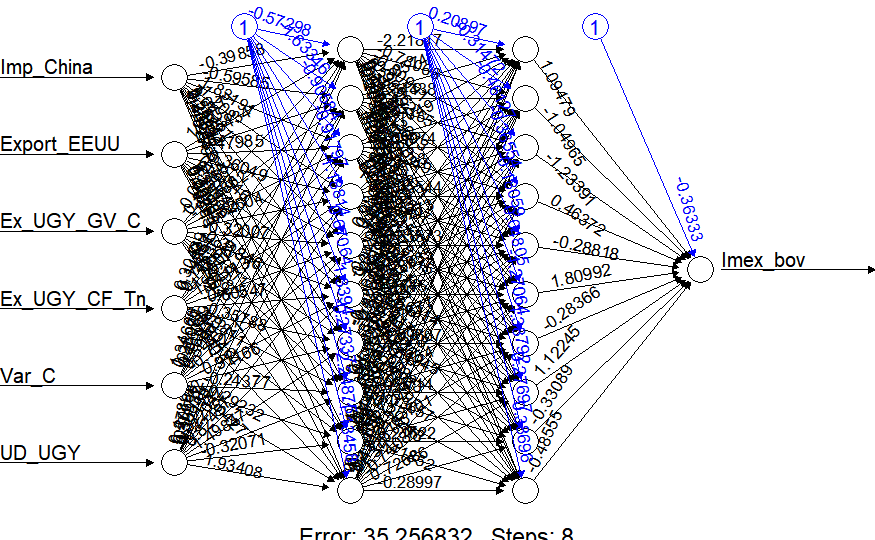

```r
plot(Neural)
```

> Comparamos los resultados con lo observado

```r
head(data.frame(prediccion=Neural$net.result[[1]], verdadero = training$Imex_bov))
```

```
##   prediccion verdadero
## 1  0.9995851     1.810
## 2  0.9999873     1.610
## 3  0.9999898     1.420
## 6  0.9999990     1.976
## 7  0.9999988     2.451
## 9  0.9999984     2.493
```

Tal como se observa los resultados de la primera red estan aproximados pero lejos de los resultados observados en la realidad, pasaremos al siguiente algoritmo

### Algotirmo NNet 5

Para este algoritmo usaremos otra tecnica en la particion de los datos, igualmente tomaremos el 80% para entrenar y el restante para validar, pero en esta oportunidad lo haremos con la funcion *createDatapartition* de la libreria caret.

```r
set.seed(123)

split <- createDataPartition(dfr5$Imex_bov,
                             p = 0.8,
                             list = FALSE)

train <- dfr5[split,]
test2 <- dfr5[-split,]
print(train)
```

```
##     Imp_China Export_EEUU Ex_UGY_GV_C Ex_UGY_CF_Tn       Var_C      UD_UGY
## 2  -0.6587481  0.37347348  -1.1869906  -1.72789060 -0.24120919  0.05733514
## 3  -0.6586892 -0.49038896  -1.1869239  -1.08197174 -0.98566057  0.33691461
## 4  -0.6593884 -0.91918492  -0.9282280  -0.07542346 -0.63686167 -0.04684777
## 5  -0.6595400 -0.97380019  -1.1894656   0.73013056  0.25856237 -0.34489004
## 6  -0.6597001 -0.80270146  -0.8592435   1.21861080 -0.30368063 -0.30532690
## 7  -0.6581753 -0.69843760  -0.9038443   0.11278571 -1.48803511 -0.69040806
## 8  -0.6552267 -0.45029773   0.1091141   0.02813382  0.04251529 -0.31323953
## 9  -0.6554710 -0.75073629   0.2577332   0.31648341 -0.50671283 -0.93701825
## 10 -0.6422616 -0.56117777   1.9246773  -0.08882809 -1.14964811 -0.87503601
## 11 -0.6418572  0.05588502   0.2783586  -0.47085985 -0.66549442 -0.90141143
## 12 -0.5733670  0.05818946   0.2914004   0.04820321  0.34706358 -0.96734999
## 14  0.1621606 -0.44868463   1.0719133  -0.33791377  1.19563404 -0.31323953
## 15  0.1728270 -0.66212445   0.5202459  -0.07261750  0.89889468  0.42263473
## 17  0.3919275  0.06927504   1.2281659   0.50025310  2.19517715  0.27229483
```

[output cut: 21 more lines]

Vamos a construir dos pruebas en la primera intentaremos con 5 neuronas de capa oculta y en la segunda con un numero mayor, ademas le indicaremos que use todas las variables obtenidas en el dataset

```r
mod_nnet1 <- nnet(Imex_bov ~ ., data = train, size = 5, maxit = 1000, linout = TRUE)
```

> Evaluacion del modelo

crearemos las predicciones

```r
predict_nnet1<- predict(mod_nnet1, newdata = test2)
```

```r
rmse1 <- caret::RMSE(predict_nnet1, test2$Imex_bov)
print(rmse1)
```

```
## [1] 0.9175643
```

> Comparamos las predicciones nnet1 con lo observado

```r
head(data.frame(predicc=predict_nnet1, verdadero = test2$Imex_bov ))
```

```
##     predicc verdadero
## 1  3.507560     1.810
## 13 3.172729     3.854
## 16 3.528920     3.382
## 20 3.568514     3.552
```

```r
print(paste(' El rrror medio cuadratico es:', rmse1))
```

```
## [1] " El rrror medio cuadratico es: 0.917564255370281"
```

Se obtienen muy buenos resultados con este algoritmo, probemos ahora con mas neuronas

### Algoritmo Nnet 50

Le inidicaremos 50 neuronas en las capas ocultas y nuevamente 1000 iteraciones como maximo

```r
mod_nnet2 <- nnet(Imex_bov ~., data = train, size = 50, maxit = 1000, linout= TRUE)
```

> Evaluemos este nuevo modelo

```r
predict_nnet2 <- predict(mod_nnet2, newdata = test2)
```

```r
rmse2 <- caret::RMSE(predict_nnet2, test2$Imex_bov)
```

```r
print(paste(' El error medio cuadratico es:', rmse2))
```

```
## [1] " El error medio cuadratico es: 1.39844469136011"
```

Aumentando el numero de neuronas el algoritmo empeora en la precision de las predicciones y pasa de un error de 0.91 a 1.39

```r
head(data.frame(predicc2=predict_nnet2, verdadero = test2$Imex_bov ))
```

```
##    predicc2 verdadero
## 1  4.542007     1.810
## 13 3.496841     3.854
## 16 3.724975     3.382
## 20 3.888950     3.552
```

## Dataset Final

```r
#test2$predict_RF <- py$Predic1
#test2$predict_nnet5 <- predict_nnet1

#print(test2)
```

### Dataset artificial para las predicciones del 2022-2025

Para sacar las predicciones futuras en el periodo que nos hemos planteado, crearemos un Dataset artificial o sintentico en excel usando la funcion pronostico lineal. Obteniendo como resultado el Dataset que usaremos para proyectar nuestros valores de IMEx en el periodo indicado.

> Visual del Dataset artificial

```python
Futuro = pd.read_excel("C:/Users/maria/OneDrive/Escritorio/Sourceowm/Capacitaciones/DDS/Proyecto/Proyecto/Futuro.xlsx")
```

```python
print(Futuro)
```

```
##    Anio      Imp_China   Export_ EEUU  ...    U$D/UGY  Imex_bov  Var_anual_Imex_bov
## 0  2022  252696.482286  233539.876190  ...  38.700000       NaN            0.077562
## 1  2023  277328.936531  297868.552608  ...  40.250000       NaN            0.084825
## 2  2024  303053.156123  333086.702492  ...  38.978667       NaN            0.069785
## 3  2025  329718.637496  358633.196841  ...  41.061698       NaN            0.048267
##
## [4 rows x 11 columns]
```

### Predicciones 2022-2025

Ya cargado el dataset crearemos las primeras predicciones para el periodo planteado, para ello debemos tratar de la misma manera cada vez que nos toque cada algoritmo segun su entrenamiento

#### Random Forest

Para el caso de este algoritmo no se le realizo ningun tratamiento a los datos, soportandonos en sus bondades para el procesamiento de datos, por lo tanto continuaremos de forma directa con la prediccion

> Extraemos las variables objetivo y año del dataset

```python
FuturoRF = Futuro.drop(['Imex_bov', 'Anio'], axis = 1)
```

```python
Predic1 = RF_mod.predict(X = FuturoRF)
```

```python
print(Predic1)
```

```
## [4.16655 4.187   4.22502 4.17031]
```

Finalmente insertaremos la prediccion en el dataset artificial

```python
Final = Futuro.copy(deep=True)
Final['predic_RF'] = Predic1
Final
```

```
##    Anio      Imp_China   Export_ EEUU  ...  Imex_bov  Var_anual_Imex_bov  predic_RF
## 0  2022  252696.482286  233539.876190  ...       NaN            0.077562    4.16655
## 1  2023  277328.936531  297868.552608  ...       NaN            0.084825    4.18700
## 2  2024  303053.156123  333086.702492  ...       NaN            0.069785    4.22502
## 3  2025  329718.637496  358633.196841  ...       NaN            0.048267    4.17031
##
## [4 rows x 12 columns]
```

Exportamos el Dataset con todas las predicciones

```python
#Final.to_excel('Predicciones_Imex.xlsx', sheet_name='Predicciones')
```

### Interpretacion y Conclusiones

> **Matriz de valoración 2.023**

Fuente: Elaboracion propia

[output not shown]

A pesar de obtener menos rentabilidad de la esperada, esta es mayor a la que podria obtener respecto a la inversion en un instrumento de plazo fijo en la banca privada.

### Presentacion de resultados finales

Visual de las predicciones finales obtenidas para el periodo consultado

```python
Final[['Anio','predic_RF']]
```

```
##    Anio  predic_RF
## 0  2022    4.16655
## 1  2023    4.18700
## 2  2024    4.22502
## 3  2025    4.17031
```

```r
#dfr4 dataset de R
#"C:/Users/maria/OneDrive/Escritorio/Sourceowm/Capacitaciones/DDS/Proyecto/Proyecto/DFF.xlsx"
```